# National Waste Report 2022 - Data Analysis

Exploring Waste Generation, Recovery, and Fate Across Australian States

Tayeb Hossain

01 October 2026

# Introduction

This project analyses the National Waste Report 2022 dataset (Wastes.csv and Year_State_ID.csv), covering Australian waste generation, recovery, and fate across states from 2006–2021. The goal is to understand how waste composition, disposal outcomes, and environmental impact vary across categories and states, and what factors help explain long-term trends in the data. Before exploring these questions, the datasets were inspected for data quality issues, cleaned with justified wrangling decisions, and joined into a single analysis dataset.

## STEP 1: SETUP & IMPORT

```r
# Load library
library(tidyverse)
# Import the two raw datasets
wastes <- read_csv("data/Wastes.csv")
year_state <- read_csv("data/Year_State_ID.csv")
```

## STEP 2: INITIAL DATA INSPECTION

```r
# --- Number of rows and columns ---
dim(wastes)       # rows x columns in Wastes.csv
```

```
## [1] 36718     9
```

```r
dim(year_state)   # rows x columns in Year_State_ID.csv
```

```
## [1] 130   4
```

```r
# --- Column names ---
colnames(wastes)
```

```
## [1] "Case_ID"       "Year_State_ID" "Category"      "Type"
## [5] "Stream"        "Fate"          "Tonnes"        "Core_Non-core"
## [9] "Description"
```

```r
colnames(year_state)
```

```
## [1] "ID"              "Year"            "State"           "Economic_Growth"
```

```r
# --- Structure of each dataset (data types per column) ---
str(wastes)
```

```
## spc_tbl_ [36,718 × 9] (S3: spec_tbl_df/tbl_df/tbl/data.frame)
##  $ Case_ID      : num [1:36718] 34658 34659 34662 34663 34664 ...
##  $ Year_State_ID: num [1:36718] 1001 1001 1001 1001 1001 ...
##  $ Category     : chr [1:36718] "Biosolids" "Biosolids" "Building and demolition materials" "Building and demolition materials" ...
##  $ Type         : chr [1:36718] "Biosolids" "Biosolids" "Asphalt" "Asphalt" ...
##  $ Stream       : chr [1:36718] "C&I" "C&I" "C&D" "C&I" ...
##  $ Fate         : chr [1:36718] "Disposal" "Recycling" "Recycling" "Recycling" ...
##  $ Tonnes       : num [1:36718] 20186 0 0 0 0 ...
##  $ Core_Non-core: chr [1:36718] "Core waste" "Core waste" "Core waste" "Core waste" ...
##  $ Description  : chr [1:36718] "A total of 20185.55 tonnes of Biosolids (C&I) was sent for Disposal. Environmental Impact Score: 2/10. This app"| __truncated__ "A total of 0.00 tonnes of Biosolids (C&I) was sent for Recycling. Environmental Impact Score: 5/10. You're on t"| __truncated__ "A tota…
##  - attr(*, "spec")=
##   .. cols(
##   ..   Case_ID = col_double(),
##   ..   Year_State_ID = col_double(),
##   ..   Category = col_character(),
##   ..   Type = col_character(),
##   ..   Stream = col_character(),
##   ..   Fate = col_character(),
##   ..   Tonnes = col_double(),
##   ..   `Core_Non-core` = col_character(),
##   ..   Description = col_character()
##   .. )
##  - attr(*, "problems")=<externalptr>
```

```r
str(year_state)
```

```
## spc_tbl_ [130 × 4] (S3: spec_tbl_df/tbl_df/tbl/data.frame)
##  $ ID             : num [1:130] 1001 1002 1003 1004 1005 ...
##  $ Year           : chr [1:130] "2020-2021" "2020-2021" "2020-2021" "2020-2021" ...
##  $ State          : chr [1:130] "ACT" "Australia" "NSW" "NT" ...
##  $ Economic_Growth: num [1:130] 1.07 -0.03 -0.88 -0.49 -0.1 -1.31 -0.52 -0.87 -1.02 1.14 ...
##  - attr(*, "spec")=
##   .. cols(
##   ..   ID = col_double(),
##   ..   Year = col_character(),
##   ..   State = col_character(),
##   ..   Economic_Growth = col_double()
##   .. )
##  - attr(*, "problems")=<externalptr>
```

```r
# --- Preview first few rows ---
head(wastes)
```

| Case_ID | Year_State_ID | Category | Type | Stream | Fate | Tonnes | Core_Non-core | Description |
| --- | --- | --- | --- | --- | --- | --- | --- | --- |
| 34658 | 1001 | Biosolids | Biosolids | C&I | Disposal | 20185.55 | Core waste | A total of 20185.55 tonnes of Biosolids (C&I) was sent for Disposal. Environmental Impact Score: 2/10. This approach negatively affects the environment. Rethink disposal methods. |
| 34659 | 1001 | Biosolids | Biosolids | C&I | Recycling | 0.00 | Core waste | A total of 0.00 tonnes of Biosolids (C&I) was sent for Recycling. Environmental Impact Score: 5/10. You're on the right track, but optimizing waste management could help. |
| 34662 | 1001 | Building and demolition materials | Asphalt | C&D | Recycling | 0.00 | Core waste | A total of 0.00 tonnes of Asphalt (C&D) was sent for Recycling. Environmental Impact Score: 5/10. This has a balanced impact, but there's room for improvement. |
| 34663 | 1001 | Building and demolition materials | Asphalt | C&I | Recycling | 0.00 | Core waste | A total of 0.00 tonnes of Asphalt (C&I) was sent for Recycling. Environmental Impact Score: 5/10. Neutral outcome—look for opportunities to reduce waste. |
| 34664 | 1001 | Building and demolition materials | Asphalt | MSW | Recycling | 0.00 | Core waste | A total of 0.00 tonnes of Asphalt (MSW) was sent for Recycling. Environmental Impact Score: 5/10. Neutral outcome—look for opportunities to reduce waste. |
| 34666 | 1001 | Building and demolition materials | Bricks, concrete and pavers | C&D | Recycling | -20000000.00 | Core waste | A total of 141663.39 tonnes of Bricks, concrete and pavers (C&D) was sent for Recycling. Environmental Impact Score: 8/10. You're making a positive impact on the environment! |

```r
tail(wastes)
```

| Case_ID | Year_State_ID | Category | Type | Stream | Fate | Tonnes | Core_Non-core | Description |
| --- | --- | --- | --- | --- | --- | --- | --- | --- |
| 88878 | 1122 | Textiles, leather & rubber (excl. tyres) | Leather & rubber (excl. tyres) | C&D | Recycling | 0 | Core waste | A total of 0.00 tonnes of Leather & rubber (excl. tyres) (C&D) was sent for Recycling. Environmental Impact Score: 5/10. This has a balanced impact, but there's room for improvement. |
| 88879 | 1122 | Textiles, leather & rubber (excl. tyres) | Leather & rubber (excl. tyres) | C&I | Recycling | 0 | Core waste | A total of 0.00 tonnes of Leather & rubber (excl. tyres) (C&I) was sent for Recycling. Environmental Impact Score: 5/10. Neutral outcome—look for opportunities to reduce waste. |
| 88880 | 1122 | Textiles, leather & rubber (excl. tyres) | Leather & rubber (excl. tyres) | MSW | Recycling | 0 | Core waste | A total of 0.00 tonnes of Leather & rubber (excl. tyres) (MSW) was sent for Recycling. Environmental Impact Score: 5/10. A stable approach, but more can be done for better environmental outcomes. |
| 88882 | 1122 | Textiles, leather & rubber (excl. tyres) | Textiles | C&D | Recycling | 0 | Core waste | A total of 0.00 tonnes of Textiles (C&D) was sent for Recycling. Environmental Impact Score: 5/10. You're on the right track, but optimizing waste management could help. |
| 88883 | 1122 | Textiles, leather & rubber (excl. tyres) | Textiles | C&I | Recycling | 0 | Core waste | A total of 0.00 tonnes of Textiles (C&I) was sent for Recycling. Environmental Impact Score: 5/10. You're on the right track, but optimizing waste management could help. |
| 88884 | 1122 | Textiles, leather & rubber (excl. tyres) | Textiles | MSW | Recycling | 0 | Core waste | A total of 0.00 tonnes of Textiles (MSW) was sent for Recycling. Environmental Impact Score: 5/10. This has a balanced impact, but there's room for improvement. |

```r
head(year_state)
```

| ID | Year | State | Economic_Growth |
| --- | --- | --- | --- |
| 1001 | 2020-2021 | ACT | 1.07 |
| 1002 | 2020-2021 | Australia | -0.03 |
| 1003 | 2020-2021 | NSW | -0.88 |
| 1004 | 2020-2021 | NT | -0.49 |
| 1005 | 2020-2021 | Qld | -0.10 |
| 1006 | 2020-2021 | SA | -1.31 |

```r
tail(year_state)
```

| ID | Year | State | Economic_Growth |
| --- | --- | --- | --- |
| 1125 | 2005-2008 | NT | 2.64 |
| 1126 | 2005-2009 | Qld | 3.51 |
| 1127 | 2005-2010 | SA | 1.62 |
| 1128 | 2005-2011 | Tas | 2.92 |
| 1129 | 2005-2012 | Vic | 2.36 |
| 1130 | 2005-2013 | WA | 2.32 |

```r
# --- Structural summary (types + values) ---
glimpse(wastes)
```

```
## Rows: 36,718
## Columns: 9
## $ Case_ID         <dbl> 34658, 34659, 34662, 34663, 34664, 34666, 34667, 34668…
## $ Year_State_ID   <dbl> 1001, 1001, 1001, 1001, 1001, 1001, 1001, 1001, 1001, …
## $ Category        <chr> "Biosolids", "Biosolids", "Building and demolition mat…
## $ Type            <chr> "Biosolids", "Biosolids", "Asphalt", "Asphalt", "Aspha…
## $ Stream          <chr> "C&I", "C&I", "C&D", "C&I", "MSW", "C&D", "C&I", "MSW"…
## $ Fate            <chr> "Disposal", "Recycling", "Recycling", "Recycling", "Re…
## $ Tonnes          <dbl> 2.018555e+04, 0.000000e+00, 0.000000e+00, 0.000000e+00…
## $ `Core_Non-core` <chr> "Core waste", "Core waste", "Core waste", "Core waste"…
## $ Description     <chr> "A total of 20185.55 tonnes of Biosolids (C&I) was sen…
```

```r
glimpse(year_state)
```

```
## Rows: 130
## Columns: 4
## $ ID              <dbl> 1001, 1002, 1003, 1004, 1005, 1006, 1007, 1008, 1009, …
## $ Year            <chr> "2020-2021", "2020-2021", "2020-2021", "2020-2021", "2…
## $ State           <chr> "ACT", "Australia", "NSW", "NT", "Qld", "SA", "Tas", "…
## $ Economic_Growth <dbl> 1.07, -0.03, -0.88, -0.49, -0.10, -1.31, -0.52, -0.87,…
```

```r
# --- Summary statistics (numeric ranges, NA counts) ---
summary(wastes)
```

```
##     Case_ID      Year_State_ID    Category             Type
##  Min.   :34658   Min.   :1001   Length:36718       Length:36718
##  1st Qu.:48294   1st Qu.:1028   Class :character   Class :character
##  Median :61793   Median :1057   Mode  :character   Mode  :character
##  Mean   :61826   Mean   :1059
##  3rd Qu.:75369   3rd Qu.:1091
##  Max.   :88884   Max.   :1122
##  NA's   :1       NA's   :1
##     Stream              Fate               Tonnes          Core_Non-core
##  Length:36718       Length:36718       Min.   :-20000000   Length:36718
##  Class :character   Class :character   1st Qu.:        0   Class :character
##  Mode  :character   Mode  :character   Median :        0   Mode  :character
##                                        Mean   :    15512
##                                        3rd Qu.:       86
##                                        Max.   :  4814588
##                                        NA's   :15
##  Description
##  Length:36718
##  Class :character
##  Mode  :character
##
##
##
##
```

```r
summary(year_state)
```

```
##        ID           Year              State           Economic_Growth
##  Min.   :1001   Length:130         Length:130         Min.   :-1.310
##  1st Qu.:1033   Class :character   Class :character   1st Qu.: 1.623
##  Median :1066   Mode  :character   Mode  :character   Median : 2.360
##  Mean   :1066                                         Mean   : 2.318
##  3rd Qu.:1098                                         3rd Qu.: 2.965
##  Max.   :1130                                         Max.   : 4.960
```

## Comment:

- Wastes.csv (36,718 rows, 9 columns) and Year_State_ID.csv (130 rows, 4 columns) were imported.
- Initial inspection showed Tonnes and Case_ID stored as numeric, Year stored as character text in financial-year format (e.g. “2020-2021”), and State including a national aggregate value, “Australia”, alongside individual states/territories.

## STEP 3: DATA QUALITY INVESTIGATION - MISSING VALUES

```r
# Count of missing (NA) values per column in each dataset
colSums(is.na(wastes))
```

```
##       Case_ID Year_State_ID      Category          Type        Stream
##             1             1             3             0             1
##          Fate        Tonnes Core_Non-core   Description
##             1            15            15             1
```

```r
colSums(is.na(year_state))
```

```
##              ID            Year           State Economic_Growth
##               0               0               0               0
```

## Comment:

- Wastes.csv contained missing values in Case_ID/Year_State_ID (1), Category (3), Stream (1), Fate (1), Tonnes (15), Core_Non-core (15), and Description (1). Investigation showed all these traced back to a single invalid record (“Space debris”/“Defunct satellites”, entirely blank) plus genuinely incomplete but otherwise valid records.
- Year_State_ID.csv had no missing values.

```r
# Inspect the specific rows where key identifiers are missing
wastes %>% filter(is.na(Case_ID) | is.na(Year_State_ID)) %>% print(width = Inf)
```

```
## # A tibble: 1 × 9
##   Case_ID Year_State_ID Category     Type               Stream Fate  Tonnes
##     <dbl>         <dbl> <chr>        <chr>              <chr>  <chr>  <dbl>
## 1      NA            NA Space debris Defunct satellites <NA>   <NA>      NA
##   `Core_Non-core` Description
##   <chr>           <chr>
## 1 <NA>            <NA>
```

```r
# Inspect rows missing each other column individually
# Row(s) missing Category
wastes %>% filter(is.na(Category)) %>% print(width = Inf)
```

```
## # A tibble: 3 × 9
##   Case_ID Year_State_ID Category Type
##     <dbl>         <dbl> <chr>    <chr>
## 1   64013          1062 <NA>     Other soil/sludges (other N)
## 2   64020          1062 <NA>     Paints, resins, inks, organic sludges (F)
## 3   64021          1062 <NA>     Paints, resins, inks, organic sludges (F)
##   Stream Fate      Tonnes `Core_Non-core`
##   <chr>  <chr>      <dbl> <chr>
## 1 C&I    Recycling  4482. Core waste
## 2 C&D    Disposal      0  Core waste
## 3 C&D    Disposal      0  Core waste
##   Description
##   <chr>
## 1 A total of 4482.23 tonnes of Other soil/sludges (other N) (C&I) was sent for …
## 2 A total of 0.00 tonnes of Paints, resins, inks, organic sludges (F) (C&D) was…
## 3 A total of 0.00 tonnes of Paints, resins, inks, organic sludges (F) (C&D) was…
```

```r
# Row(s) missing Stream
wastes %>% filter(is.na(Stream)) %>% print(width = Inf)
```

```
## # A tibble: 1 × 9
##   Case_ID Year_State_ID Category     Type               Stream Fate  Tonnes
##     <dbl>         <dbl> <chr>        <chr>              <chr>  <chr>  <dbl>
## 1      NA            NA Space debris Defunct satellites <NA>   <NA>      NA
##   `Core_Non-core` Description
##   <chr>           <chr>
## 1 <NA>            <NA>
```

```r
# Row(s) missing Fate
wastes %>% filter(is.na(Fate)) %>% print(width = Inf)
```

```
## # A tibble: 1 × 9
##   Case_ID Year_State_ID Category     Type               Stream Fate  Tonnes
##     <dbl>         <dbl> <chr>        <chr>              <chr>  <chr>  <dbl>
## 1      NA            NA Space debris Defunct satellites <NA>   <NA>      NA
##   `Core_Non-core` Description
##   <chr>           <chr>
## 1 <NA>            <NA>
```

```r
# Rows missing Tonnes
wastes %>% filter(is.na(Tonnes)) %>% print(width = Inf)
```

```
## # A tibble: 15 × 9
##    Case_ID Year_State_ID Category         Type                            Stream
##      <dbl>         <dbl> <chr>            <chr>                           <chr>
##  1   35085          1001 Hazardous wastes Tyres (T140)                    C&I
##  2   35086          1001 Hazardous wastes Tyres (T140)                    C&I
##  3   35087          1001 Hazardous wastes Tyres (T140)                    C&I
##  4   55143          1043 Hazardous wastes Asbestos (N220)                 C&I
##  5   55144          1043 Hazardous wastes Asbestos (N220)                 C&I
##  6   55151          1043 Hazardous wastes Clinical and pharmaceutical (R) C&D
##  7   55152          1043 Hazardous wastes Clinical and pharmaceutical (R) C&D
##  8   55153          1043 Hazardous wastes Clinical and pharmaceutical (R) C&D
##  9   55154          1043 Hazardous wastes Clinical and pharmaceutical (R) C&D
## 10   55155          1043 Hazardous wastes Clinical and pharmaceutical (R) C&D
## 11   55156          1043 Hazardous wastes Clinical and pharmaceutical (R) C&D
## 12   66026          1066 Organics         Other organics                  MSW
```

[output cut: 37 more lines]

```r
# Rows missing Core_Non-core
wastes %>% filter(is.na(`Core_Non-core`)) %>% print(width = Inf)
```

```
## # A tibble: 15 × 9
##    Case_ID Year_State_ID Category         Type               Stream
##      <dbl>         <dbl> <chr>            <chr>              <chr>
##  1   34696          1001 Hazardous wastes Acids (B)          C&D
##  2   34697          1001 Hazardous wastes Acids (B)          C&D
##  3   34698          1001 Hazardous wastes Acids (B)          C&D
##  4   34699          1001 Hazardous wastes Acids (B)          C&D
##  5   34700          1001 Hazardous wastes Acids (B)          C&D
##  6   34701          1001 Hazardous wastes Acids (B)          C&D
##  7   34702          1001 Hazardous wastes Acids (B)          C&D
##  8   34703          1001 Hazardous wastes Acids (B)          C&I
##  9   34704          1001 Hazardous wastes Acids (B)          C&I
## 10   34705          1001 Hazardous wastes Acids (B)          C&I
## 11   34706          1001 Hazardous wastes Acids (B)          C&I
## 12   34707          1001 Hazardous wastes Acids (B)          C&I
```

[output cut: 37 more lines]

```r
# Row missing Description
wastes %>% filter(is.na(Description)) %>% print(width = Inf)
```

```
## # A tibble: 1 × 9
##   Case_ID Year_State_ID Category     Type               Stream Fate  Tonnes
##     <dbl>         <dbl> <chr>        <chr>              <chr>  <chr>  <dbl>
## 1      NA            NA Space debris Defunct satellites <NA>   <NA>      NA
##   `Core_Non-core` Description
##   <chr>           <chr>
## 1 <NA>            <NA>
```

```r
# Check Year_State_ID.csv for missing values in its own columns
year_state %>% filter(if_any(everything(), is.na)) %>% print(width = Inf)
```

```
## # A tibble: 0 × 4
## # ℹ 4 variables: ID <dbl>, Year <chr>, State <chr>, Economic_Growth <dbl>
```

## STEP 4: DUPLICATE CHECK

```r
# Check for fully duplicated rows across all columns
sum(duplicated(wastes))
```

```
## [1] 0
```

```r
# Check whether Case_ID has duplicates
sum(duplicated(wastes$Case_ID, incomparables = NA))
```

```
## [1] 11
```

```r
# Show the actual duplicated Case_ID rows for inspection
wastes %>%
  filter(Case_ID %in% Case_ID[duplicated(Case_ID) & !is.na(Case_ID)]) %>%
  arrange(Case_ID) %>%
  print(width = Inf)
```

```
## # A tibble: 21 × 9
##    Case_ID Year_State_ID Category          Type                  Stream
##      <dbl>         <dbl> <chr>             <chr>                 <chr>
##  1   62399          1058 Paper & cardboard Cardboard             C&D
##  2   62399          1058 Paper & cardboard Cardboard             C&D
##  3   62399          1058 Paper & cardboard Cardboard             C&D
##  4   62400          1058 Paper & cardboard Cardboard             C&I
##  5   62400          1058 Paper & cardboard Cardboard             C&I
##  6   62401          1058 Paper & cardboard Cardboard             MSW
##  7   62401          1058 Paper & cardboard Cardboard             MSW
##  8   62403          1058 Paper & cardboard Newsprint & magazines C&D
##  9   62403          1058 Paper & cardboard Newsprint & magazines C&D
## 10   62404          1058 Paper & cardboard Newsprint & magazines C&I
##    Fate      Tonnes `Core_Non-core`
##    <chr>      <dbl> <chr>
```

[output cut: 23 more lines]

```r
# Check Year_State_ID.csv for duplicate IDs
sum(duplicated(year_state$ID))
```

```
## [1] 0
```

## STEP 5a: CATEGORICAL VARIABLE CHECK

```r
# Unique values in each categorical column to spot
# inconsistent labels or invalid entries

unique(wastes$Category)
```

```
##  [1] "Biosolids"
##  [2] "Building and demolition materials"
##  [3] "Building & demolition materials"
##  [4] "Glass"
##  [5] "Hazardous wastes"
##  [6] "Metals"
##  [7] "Organics"
##  [8] "Plastics"
##  [9] "Textiles, leather & rubber (excl. tyres)"
## [10] "Ash"
## [11] "Paper & cardboard"
## [12] "Aluminium"
## [13] "organics"
## [14] "Unclassified materials"
## [15] "Metals & Organics"
## [16] "HW"
## [17] NA
## [18] "Toxic wastes"
## [19] "Space debris"
## [20] "Plastic"
## [21] "Recycling"
```

```r
unique(wastes$Type)
```

```
##  [1] "Biosolids"
##  [2] "Asphalt"
##  [3] "Bricks, concrete and pavers"
##  [4] "Ceramics, tiles and pottery"
##  [5] "Plasterboard & cement sheeting"
##  [6] "Rubble"
##  [7] "Soil, sand and rock not contaminated above any threshold requiring classification as contaminated soils (N120)"
##  [8] "Glass from food and beverage containers"
##  [9] "Other glass"
## [10] "Acids (B)"
## [11] "Alkalis (C)"
## [12] "Asbestos (N220)"
## [13] "Clinical and pharmaceutical (R)"
## [14] "Contaminated soils (N120)"
## [15] "Food-derived hazardous wastes (K100, K110)"
```

[output cut: 37 more lines]

```r
unique(wastes$Stream)
```

```
## [1] "C&I"                               "C&D"
## [3] "MSW"                               "Construction and demolition waste"
## [5] "Municipal solid waste"             NA
```

```r
unique(wastes$Fate)
```

```
## [1] "Disposal"          "Recycling"         "Waste reuse"
## [4] "Energy recovery"   "Long-term storage" NA
```

```r
unique(wastes$`Core_Non-core`)
```

```
## [1] "Core waste"     NA               "Non-core waste"
```

```r
# Count how many rows fall into each Category value
wastes %>% count(Category, sort = TRUE)
```

| Category | n |
| --- | --- |
| Hazardous wastes | 28066 |
| Organics | 4213 |
| Plastics | 943 |
| Building and demolition materials | 927 |
| Metals | 714 |
| Paper & cardboard | 696 |
| Textiles, leather & rubber (excl. tyres) | 380 |
| Glass | 309 |
| Biosolids | 192 |
| Unclassified materials | 137 |

[output cut: 11 more lines]

```r
# For Stream and Fate
wastes %>% count(Stream, sort = TRUE)
```

| Stream | n |
| --- | --- |
| C&I | 17213 |
| C&D | 16781 |
| MSW | 2721 |
| Construction and demolition waste | 1 |
| Municipal solid waste | 1 |
| NA | 1 |

```r
wastes %>% count(Fate, sort = TRUE)
```

| Fate | n |
| --- | --- |
| Disposal | 15122 |
| Recycling | 13941 |
| Energy recovery | 7575 |
| Long-term storage | 60 |
| Waste reuse | 19 |
| NA | 1 |

```r
# Check Core_Non-core values
wastes %>% count(`Core_Non-core`, sort = TRUE)
```

| Core_Non-core | n |
| --- | --- |
| Core waste | 36578 |
| Non-core waste | 125 |
| NA | 15 |

```r
# Check the categorical columns in Year_State_ID.csv
unique(year_state$State)
```

```
## [1] "ACT"       "Australia" "NSW"       "NT"        "Qld"       "SA"
## [7] "Tas"       "Vic"       "WA"
```

```r
unique(year_state$Year)
```

```
##  [1] "2020-2021" "2019-2020" "2018-2019" "2017-2018" "2016-2017" "2015-2016"
##  [7] "2014-2015" "2013-2014" "2012-2013" "2011-2012" "2010-2011" "2009-2010"
## [13] "2008-2009" "2007-2008" "2006-2007" "2005-2006" "2005-2007" "2005-2008"
## [19] "2005-2009" "2005-2010" "2005-2011" "2005-2012" "2005-2013"
```

## Comment:

Category contained 21 raw values due to inconsistent capitalisation (Organics/organics), inconsistent spelling (Plastics/Plastic), and duplicate labels for the same concepts. Two invalid entries were also identified: “Recycling” (a Fate value) and “Metals & Organics.” Stream similarly mixed abbreviations (C&D, C&I, MSW) with full names for two rows. Fate and Core_Non-core had no inconsistencies beyond the missing values already noted.

## STEP 5b: FREQUENCY COUNTS + YEAR ANOMALY INVESTIGATION

```r
# Frequency counts for key categorical columns
print(wastes %>% count(Category, sort = TRUE), n = Inf)
```

```
## # A tibble: 21 × 2
##    Category                                     n
##    <chr>                                    <int>
##  1 Hazardous wastes                         28066
##  2 Organics                                  4213
##  3 Plastics                                   943
##  4 Building and demolition materials          927
##  5 Metals                                     714
##  6 Paper & cardboard                          696
##  7 Textiles, leather & rubber (excl. tyres)   380
##  8 Glass                                      309
##  9 Biosolids                                  192
## 10 Unclassified materials                     137
## 11 Ash                                        125
## 12 Aluminium                                    3
## 13 <NA>                                         3
## 14 Recycling                                    2
## 15 organics                                     2
## 16 Building & demolition materials              1
## 17 HW                                           1
## 18 Metals & Organics                            1
## 19 Plastic                                      1
## 20 Space debris                                 1
## 21 Toxic wastes                                 1
```

```r
print(wastes %>% count(Stream, sort = TRUE), n = Inf)
```

```
## # A tibble: 6 × 2
##   Stream                                n
##   <chr>                             <int>
## 1 C&I                               17213
## 2 C&D                               16781
## 3 MSW                                2721
## 4 Construction and demolition waste     1
## 5 Municipal solid waste                 1
## 6 <NA>                                  1
```

```r
print(wastes %>% count(Fate, sort = TRUE), n = Inf)
```

```
## # A tibble: 6 × 2
##   Fate                  n
##   <chr>             <int>
## 1 Disposal          15122
## 2 Recycling         13941
## 3 Energy recovery    7575
## 4 Long-term storage    60
## 5 Waste reuse          19
## 6 <NA>                  1
```

```r
print(wastes %>% count(`Core_Non-core`, sort = TRUE), n = Inf)
```

```
## # A tibble: 3 × 2
##   `Core_Non-core`     n
##   <chr>           <int>
## 1 Core waste      36578
## 2 Non-core waste    125
## 3 <NA>               15
```

```r
# Investigate the malformed multi-year Year values in Year_State_ID.csv
year_state %>%
  filter(Year %in% c("2005-2007","2005-2008","2005-2009",
                      "2005-2010","2005-2011","2005-2012","2005-2013")) %>%
  arrange(Year, State) %>%
  print(n = Inf)
```

```
## # A tibble: 7 × 4
##      ID Year      State Economic_Growth
##   <dbl> <chr>     <chr>           <dbl>
## 1  1124 2005-2007 NSW              2.01
## 2  1125 2005-2008 NT               2.64
## 3  1126 2005-2009 Qld              3.51
## 4  1127 2005-2010 SA               1.62
## 5  1128 2005-2011 Tas              2.92
## 6  1129 2005-2012 Vic              2.36
## 7  1130 2005-2013 WA               2.32
```

```r
# Check whether these malformed years co-exist with normal years for the same States
year_state %>%
  count(State, Year) %>%
  filter(State != "Australia") %>%
  arrange(State, Year) %>%
  print(n = Inf)
```

```
## # A tibble: 128 × 3
##     State Year          n
##     <chr> <chr>     <int>
##   1 ACT   2005-2006     1
##   2 ACT   2006-2007     1
##   3 ACT   2007-2008     1
##   4 ACT   2008-2009     1
##   5 ACT   2009-2010     1
##   6 ACT   2010-2011     1
##   7 ACT   2011-2012     1
##   8 ACT   2012-2013     1
##   9 ACT   2013-2014     1
##  10 ACT   2014-2015     1
##  11 ACT   2015-2016     1
##  12 ACT   2016-2017     1
```

[output cut: 116 more lines]

## Comment:

Year_State_ID.csv contained 7 incorrect multi-year values. Based on the consistent pattern across all other states and the sequential year pattern, all 7 values were corrected to 2005-2006.

## STEP 6: NUMERICAL VARIABLE CHECK

```r
# Distribution of Tonnes
summary(wastes$Tonnes)
```

```
##      Min.   1st Qu.    Median      Mean   3rd Qu.      Max.      NA's
## -20000000         0         0     15512        86   4814588        15
```

```r
# Check negative Tonnes values
wastes %>% filter(Tonnes < 0) %>% print(width = Inf)
```

```
## # A tibble: 6 × 9
##   Case_ID Year_State_ID Category
##     <dbl>         <dbl> <chr>
## 1   34666          1001 Building and demolition materials
## 2   36735          1005 Hazardous wastes
## 3   36737          1005 Hazardous wastes
## 4   38955          1009 Hazardous wastes
## 5   58473          1050 Hazardous wastes
## 6   62166          1058 Hazardous wastes
##   Type                        Stream Fate         Tonnes `Core_Non-core`
##   <chr>                       <chr>  <chr>         <dbl> <chr>
## 1 Bricks, concrete and pavers C&D    Recycling -2   e+ 7 Core waste
## 2 Other                       C&I    Disposal  -2.02e- 8 Core waste
## 3 Other                       C&I    Recycling -2.02e-10 Core waste
## 4 Other                       C&I    Disposal  -2.13e-15 Core waste
## 5 Other                       C&I    Disposal  -9.83e-14 Core waste
## 6 Other                       C&I    Disposal  -4.98e-14 Core waste
##   Description
##   <chr>
## 1 A total of 141663.39 tonnes of Bricks, concrete and pavers (C&D) was sent for…
## 2 A total of -0.00 tonnes of Other (C&I) was sent for Disposal. Environmental I…
## 3 A total of -0.00 tonnes of Other (C&I) was sent for Recycling. Environmental …
## 4 A total of -0.00 tonnes of Other (C&I) was sent for Disposal. Environmental I…
## 5 A total of -0.00 tonnes of Other (C&I) was sent for Disposal. Environmental I…
## 6 A total of -0.00 tonnes of Other (C&I) was sent for Disposal. Environmental I…
```

```r
# Check the extreme outliers - largest positive and most negative values
wastes %>% arrange(Tonnes) %>% slice(1:5) %>% print(width = Inf)
```

```
## # A tibble: 5 × 9
##   Case_ID Year_State_ID Category
##     <dbl>         <dbl> <chr>
## 1   34666          1001 Building and demolition materials
## 2   36735          1005 Hazardous wastes
## 3   36737          1005 Hazardous wastes
## 4   58473          1050 Hazardous wastes
## 5   62166          1058 Hazardous wastes
##   Type                        Stream Fate         Tonnes `Core_Non-core`
##   <chr>                       <chr>  <chr>         <dbl> <chr>
## 1 Bricks, concrete and pavers C&D    Recycling -2   e+ 7 Core waste
## 2 Other                       C&I    Disposal  -2.02e- 8 Core waste
## 3 Other                       C&I    Recycling -2.02e-10 Core waste
## 4 Other                       C&I    Disposal  -9.83e-14 Core waste
## 5 Other                       C&I    Disposal  -4.98e-14 Core waste
##   Description
##   <chr>
## 1 A total of 141663.39 tonnes of Bricks, concrete and pavers (C&D) was sent for…
## 2 A total of -0.00 tonnes of Other (C&I) was sent for Disposal. Environmental I…
## 3 A total of -0.00 tonnes of Other (C&I) was sent for Recycling. Environmental …
## 4 A total of -0.00 tonnes of Other (C&I) was sent for Disposal. Environmental I…
## 5 A total of -0.00 tonnes of Other (C&I) was sent for Disposal. Environmental I…
```

```r
wastes %>% arrange(desc(Tonnes)) %>% slice(1:5) %>% print(width = Inf)
```

```
## # A tibble: 5 × 9
##   Case_ID Year_State_ID Category
##     <dbl>         <dbl> <chr>
## 1   48079          1028 Building and demolition materials
## 2   48056          1028 Ash
## 3   51845          1036 Building and demolition materials
## 4   79316          1100 Ash
## 5   38135          1008 Building and demolition materials
##   Type                        Stream
##   <chr>                       <chr>
## 1 Rubble                      Construction and demolition waste
## 2 Ash                         C&I
## 3 Rubble                      C&D
## 4 Ash                         C&I
## 5 Bricks, concrete and pavers C&D
##   Fate                Tonnes `Core_Non-core`
##   <chr>                <dbl> <chr>
## 1 Recycling         4814588  Core waste
## 2 Recycling         4599587. Non-core waste
## 3 Recycling         4540795  Core waste
## 4 Long-term storage 4478830. Non-core waste
## 5 Recycling         4478596. Core waste
##   Description
##   <chr>
## 1 A total of 4814588.00 tonnes of Rubble (C&D) was sent for Recycling. Environm…
## 2 A total of 4599587.01 tonnes of Ash (C&I) was sent for Recycling. Environment…
## 3 A total of 4540795.00 tonnes of Rubble (C&D) was sent for Recycling. Environm…
## 4 A total of 4478830.46 tonnes of Ash (C&I) was sent for Long-term storage. Env…
## 5 A total of 4478596.48 tonnes of Bricks, concrete and pavers (C&D) was sent fo…
```

```r
# Check for near-zero negative values
wastes %>% filter(Tonnes < 0 & Tonnes > -1) %>% print(width = Inf)
```

```
## # A tibble: 5 × 9
##   Case_ID Year_State_ID Category         Type  Stream Fate         Tonnes
##     <dbl>         <dbl> <chr>            <chr> <chr>  <chr>         <dbl>
## 1   36735          1005 Hazardous wastes Other C&I    Disposal  -2.02e- 8
## 2   36737          1005 Hazardous wastes Other C&I    Recycling -2.02e-10
## 3   38955          1009 Hazardous wastes Other C&I    Disposal  -2.13e-15
## 4   58473          1050 Hazardous wastes Other C&I    Disposal  -9.83e-14
## 5   62166          1058 Hazardous wastes Other C&I    Disposal  -4.98e-14
##   `Core_Non-core`
##   <chr>
## 1 Core waste
## 2 Core waste
## 3 Core waste
## 4 Core waste
## 5 Core waste
##   Description
##   <chr>
## 1 A total of -0.00 tonnes of Other (C&I) was sent for Disposal. Environmental I…
## 2 A total of -0.00 tonnes of Other (C&I) was sent for Recycling. Environmental …
## 3 A total of -0.00 tonnes of Other (C&I) was sent for Disposal. Environmental I…
## 4 A total of -0.00 tonnes of Other (C&I) was sent for Disposal. Environmental I…
## 5 A total of -0.00 tonnes of Other (C&I) was sent for Disposal. Environmental I…
```

```r
# Distribution of Economic_Growth
summary(year_state$Economic_Growth)
```

```
##    Min. 1st Qu.  Median    Mean 3rd Qu.    Max.
##  -1.310   1.623   2.360   2.318   2.965   4.960
```

## Comment:

Tonnes contained one extreme outlier (-20,000,000; Case_ID 34666), which was corrected based on the Description text. Five near-zero negative values were also identified as floating-point rounding errors representing “-0.00 tonnes.” No other anomalies were found in Tonnes or Economic_Growth; large positive Tonnes values were verified as legitimate.

## STEP 7: PARSE THE DESCRIPTION COLUMN

```r
# Extract the Environmental Impact Score
wastes <- wastes %>%
  mutate(
    Impact_Score = as.numeric(str_extract(Description, "(?<=Score: )\\d+(?=/10)"))
  )

# Extract the feedback sentences that come AFTER the score
wastes <- wastes %>%
  mutate(
    Feedback = str_trim(str_extract(Description, "(?<=/10\\.\\s).*"))
  )

# Extract the tonnage value written inside the Description text itself
wastes <- wastes %>%
  mutate(
    Tonnes_from_text = as.numeric(str_extract(Description, "(?<=A total of )[^\\s]+(?= tonnes)"))
  )


# How many rows failed to get a score?
sum(is.na(wastes$Impact_Score))
```

```
## [1] 1
```

```r
# Check the score range
range(wastes$Impact_Score, na.rm = TRUE)
```

```
## [1] 1 8
```

```r
# Preview the new columns
wastes %>%
  select(Case_ID, Tonnes, Tonnes_from_text, Impact_Score, Feedback) %>%
  head(10) %>%
  print(width = Inf)
```

```
## # A tibble: 10 × 5
##    Case_ID        Tonnes Tonnes_from_text Impact_Score
##      <dbl>         <dbl>            <dbl>        <dbl>
##  1   34658     20186.            20186.              2
##  2   34659         0                 0               5
##  3   34662         0                 0               5
##  4   34663         0                 0               5
##  5   34664         0                 0               5
##  6   34666 -20000000            141663.              8
##  7   34667         3.83              3.83            8
##  8   34668         0                 0               5
##  9   34670     36191.            36191.              8
## 10   34671         0.531             0.53            8
##    Feedback
##    <chr>
##  1 This approach negatively affects the environment. Rethink disposal methods.
##  2 You're on the right track, but optimizing waste management could help.
##  3 This has a balanced impact, but there's room for improvement.
##  4 Neutral outcome—look for opportunities to reduce waste.
##  5 Neutral outcome—look for opportunities to reduce waste.
##  6 You're making a positive impact on the environment!
##  7 Excellent waste management! Keep going.
##  8 A stable approach, but more can be done for better environmental outcomes.
##  9 Excellent waste management! Keep going.
## 10 You're making a positive impact on the environment!
```

```r
# Specifically check the corrupted row we found earlier (Case_ID 34666)
wastes %>%
  filter(Case_ID == 34666) %>%
  select(Case_ID, Tonnes, Tonnes_from_text, Description) %>%
  print(width = Inf)
```

```
## # A tibble: 1 × 4
##   Case_ID    Tonnes Tonnes_from_text
##     <dbl>     <dbl>            <dbl>
## 1   34666 -20000000          141663.
##   Description
##   <chr>
## 1 A total of 141663.39 tonnes of Bricks, concrete and pavers (C&D) was sent for…
```

```r
# Check the 14 rows with missing Tonnes
wastes %>%
  filter(is.na(Tonnes)) %>%
  select(Case_ID, Tonnes, Tonnes_from_text, Description) %>%
  print(width = Inf)
```

```
## # A tibble: 15 × 4
##    Case_ID Tonnes Tonnes_from_text
##      <dbl>  <dbl>            <dbl>
##  1   35085     NA              NaN
##  2   35086     NA              NaN
##  3   35087     NA              NaN
##  4   55143     NA              NaN
##  5   55144     NA              NaN
##  6   55151     NA              NaN
##  7   55152     NA              NaN
##  8   55153     NA              NaN
##  9   55154     NA              NaN
## 10   55155     NA              NaN
## 11   55156     NA              NaN
## 12   66026     NA             2370
```

[output cut: 20 more lines]

## Comment:

The Description column follows a consistent format. Three variables were extracted: Impact_Score, Feedback, and Tonnes_from_text, which was used to verify or recover Tonnes values. Of the 15 missing Tonnes values, 11 were unrecoverable (“nan”), 3 were recovered from the text, and 1 belonged to an invalid junk row.

## STEP 8: BUILD wastes_clean

```r
wastes_clean <- wastes %>%
  # 1. Remove the invalid "Space debris" junk row
  filter(!is.na(Case_ID)) %>%

  # 2. Fix the corrupted Tonnes value using the true figure from Description
  mutate(
    Tonnes = case_when(
      Case_ID == 34666 ~ Tonnes_from_text,                     # corrupted value
      is.na(Tonnes) & !is.nan(Tonnes_from_text) ~ Tonnes_from_text,
      TRUE ~ Tonnes
    )
  ) %>%

  # 3. Round tiny floating-point-noise negative values to 0
  mutate(
    Tonnes = if_else(Tonnes < 0 & Tonnes > -1, 0, Tonnes)
  ) %>%

  # 4. Standardize inconsistent Category labels
  mutate(
    Category = case_when(
      Category %in% c("organics") ~ "Organics",
      Category %in% c("Plastic") ~ "Plastics",
      Category %in% c("Building & demolition materials") ~ "Building and demolition materials",
      Category %in% c("HW", "Toxic wastes") ~ "Hazardous wastes",
      TRUE ~ Category
    )
  ) %>%

  # 5. Standardize inconsistent Stream labels to abbreviations
  mutate(
    Stream = case_when(
      Stream == "Construction and demolition waste" ~ "C&D",
      Stream == "Municipal solid waste" ~ "MSW",
      TRUE ~ Stream
    )
  ) %>%

  # 6. Impute missing Core_Non-core for the 14 "Hazardous wastes / Acids (B)" rows
  mutate(
    `Core_Non-core` = if_else(is.na(`Core_Non-core`), "Core waste", `Core_Non-core`)
  )

# --- Checks after cleaning ---
dim(wastes_clean)
```

```
## [1] 36717    12
```

```r
sort(unique(wastes_clean$Category))
```

```
##  [1] "Aluminium"
##  [2] "Ash"
##  [3] "Biosolids"
##  [4] "Building and demolition materials"
##  [5] "Glass"
##  [6] "Hazardous wastes"
##  [7] "Metals"
##  [8] "Metals & Organics"
##  [9] "Organics"
## [10] "Paper & cardboard"
## [11] "Plastics"
## [12] "Recycling"
## [13] "Textiles, leather & rubber (excl. tyres)"
## [14] "Unclassified materials"
```

```r
sort(unique(wastes_clean$Stream))
```

```
## [1] "C&D" "C&I" "MSW"
```

```r
colSums(is.na(wastes_clean))
```

```
##          Case_ID    Year_State_ID         Category             Type
##                0                0                3                0
##           Stream             Fate           Tonnes    Core_Non-core
##                0                0               11                0
##      Description     Impact_Score         Feedback Tonnes_from_text
##                0                0                0               11
```

```r
summary(wastes_clean$Tonnes)
```

```
##    Min. 1st Qu.  Median    Mean 3rd Qu.    Max.    NA's
##       0       0       0   16060      86 4814588      11
```

## Comment:

Based on these findings, wastes_clean was created by removing the invalid “Space debris” row, correcting and recovering Tonnes values, rounding near-zero negatives to 0, standardising Category and Stream labels, and imputing the 14 missing Core_Non-core values as “Core waste.” All identified issues were resolved except the remaining Category “NAs” and invalid labels, which were addressed next.

## STEP 9a: RESOLVE REMAINING CATEGORY ISSUES

```r
# Check other rows with the same Type for a Category to infer
wastes_clean %>%
  filter(Type %in% c("Other soil/sludges (other N)",
                      "Paints, resins, inks, organic sludges (F)")) %>%
  count(Type, Category)
```

| Type | Category | n |
| --- | --- | --- |
| Other soil/sludges (other N) | Hazardous wastes | 1471 |
| Other soil/sludges (other N) | NA | 1 |
| Paints, resins, inks, organic sludges (F) | Hazardous wastes | 1470 |
| Paints, resins, inks, organic sludges (F) | NA | 2 |

```r
# Inspect rows where Category = "Recycling" and their real Type/Fate
wastes_clean %>%
  filter(Category == "Recycling") %>%
  select(Case_ID, Category, Type, Stream, Fate, Description) %>%
  print(width = Inf)
```

```
## # A tibble: 2 × 6
##   Case_ID Category  Type                         Stream Fate
##     <dbl> <chr>     <chr>                        <chr>  <chr>
## 1   88874 Recycling Polyvinyl chloride (PVC) (3) C&D    Recycling
## 2   88875 Recycling Polyvinyl chloride (PVC) (3) C&I    Recycling
##   Description
##   <chr>
## 1 A total of 0.00 tonnes of Polyvinyl chloride (PVC) (3) (C&D) was sent for Rec…
## 2 A total of 0.00 tonnes of Polyvinyl chloride (PVC) (3) (C&I) was sent for Rec…
```

```r
# Inspect the single "Metals & Organics" row
wastes_clean %>%
  filter(Category == "Metals & Organics") %>%
  select(Case_ID, Category, Type, Stream, Fate, Description) %>%
  print(width = Inf)
```

```
## # A tibble: 1 × 6
##   Case_ID Category          Type          Stream Fate
##     <dbl> <chr>             <chr>         <chr>  <chr>
## 1   51725 Metals & Organics Food organics C&D    Recycling
##   Description
##   <chr>
## 1 A total of 0.00 tonnes of Food organics (C&D) was sent for Recycling. Environ…
```

```r
# Compare which Category does this Type normally belong to
wastes_clean %>%
  filter(Type == (wastes_clean %>% filter(Category == "Metals & Organics") %>% pull(Type))) %>%
  count(Type, Category)
```

| Type | Category | n |
| --- | --- | --- |
| Food organics | Metals & Organics | 1 |
| Food organics | Organics | 1068 |

```r
# Confirm PVC's Category elsewhere in the dataset
wastes_clean %>%
  filter(Type == "Polyvinyl chloride (PVC) (3)") %>%
  count(Type, Category)
```

| Type | Category | n |
| --- | --- | --- |
| Polyvinyl chloride (PVC) (3) | Plastics | 127 |
| Polyvinyl chloride (PVC) (3) | Recycling | 2 |

## STEP 9b: APPLY CATEGORY FIXES

```r
wastes_clean <- wastes_clean %>%
  mutate(
    Category = case_when(
      # Impute missing Category using Type lookup
      is.na(Category) & Type == "Other soil/sludges (other N)" ~ "Hazardous wastes",
      is.na(Category) & Type == "Paints, resins, inks, organic sludges (F)" ~ "Hazardous wastes",

      # Fix mislabeled Category values
      Category == "Recycling" & Type == "Polyvinyl chloride (PVC) (3)" ~ "Plastics",
      Category == "Metals & Organics" ~ "Organics",

      TRUE ~ Category
    )
  )

# --- Final check ---
sort(unique(wastes_clean$Category))
```

```
##  [1] "Aluminium"
##  [2] "Ash"
##  [3] "Biosolids"
##  [4] "Building and demolition materials"
##  [5] "Glass"
##  [6] "Hazardous wastes"
##  [7] "Metals"
##  [8] "Organics"
##  [9] "Paper & cardboard"
## [10] "Plastics"
## [11] "Textiles, leather & rubber (excl. tyres)"
## [12] "Unclassified materials"
```

```r
colSums(is.na(wastes_clean))
```

```
##          Case_ID    Year_State_ID         Category             Type
##                0                0                0                0
##           Stream             Fate           Tonnes    Core_Non-core
##                0                0               11                0
##      Description     Impact_Score         Feedback Tonnes_from_text
##                0                0                0               11
```

```r
dim(wastes_clean)
```

```
## [1] 36717    12
```

## Comment:

The 3 missing Category values were imputed using their Type: both associated Type values overwhelmingly mapped to “Hazardous wastes” elsewhere in the data (1471/1472 and 1470/1472 occurrences). The invalid Category value “Recycling” (Type: PVC) was corrected to “Plastics” (its Type’s dominant category, 127/129 occurrences), and “Metals & Organics” (Type: Food organics) was corrected to “Organics” (1068/1069 occurrences). After these fixes, wastes_clean contains exactly 12 valid, distinct Category values with zero missing entries.

## STEP 10: CLEAN year_state.csv

```r
# Fix the malformed multi-year Year values matching every other state's pattern
year_state_clean <- year_state %>%
  mutate(
    Year = case_when(
      Year %in% c("2005-2007", "2005-2008", "2005-2009",
                  "2005-2010", "2005-2011", "2005-2012", "2005-2013") ~ "2005-2006",
      TRUE ~ Year
    )
  )

# Check for duplicate Year per State
year_state_clean %>%
  count(State, Year) %>%
  filter(n > 1)
```

| State | Year | n |
| --- | --- | --- |

```r
sort(unique(year_state_clean$Year))
```

```
##  [1] "2005-2006" "2006-2007" "2007-2008" "2008-2009" "2009-2010" "2010-2011"
##  [7] "2011-2012" "2012-2013" "2013-2014" "2014-2015" "2015-2016" "2016-2017"
## [13] "2017-2018" "2018-2019" "2019-2020" "2020-2021"
```

```r
# ============================================================
# VALIDATE THE RELATIONSHIP BETWEEN THE TWO DATASETS
# ============================================================

# Check whether ID is unique in year_state_clean
sum(duplicated(year_state_clean$ID))
```

```
## [1] 0
```

```r
# Check whether every Year_State_ID in wastes_clean matches an ID in year_state_clean
sum(!wastes_clean$Year_State_ID %in% year_state_clean$ID)
```

```
## [1] 0
```

```r
# Check whether every ID in year_state_clean is used at least once in wastes_clean
sum(!year_state_clean$ID %in% wastes_clean$Year_State_ID)
```

```
## [1] 9
```

```r
# Which Year State combinations have no matching waste records at all?
year_state_clean %>%
  filter(!ID %in% wastes_clean$Year_State_ID) %>%
  arrange(State, Year) %>%
  print(n = Inf)
```

```
## # A tibble: 9 × 4
##      ID Year      State     Economic_Growth
##   <dbl> <chr>     <chr>               <dbl>
## 1  1123 2005-2006 ACT                  1.46
## 2  1019 2018-2019 Australia            2.3
## 3  1124 2005-2006 NSW                  2.01
## 4  1125 2005-2006 NT                   2.64
## 5  1126 2005-2006 Qld                  3.51
## 6  1127 2005-2006 SA                   1.62
## 7  1128 2005-2006 Tas                  2.92
## 8  1129 2005-2006 Vic                  2.36
## 9  1130 2005-2006 WA                   2.32
```

## Comment:

The 7 malformed Year values were corrected in year_state_clean and verified, with each state now having exactly 16 unique years. All Year_State_ID values in wastes_clean matched valid IDs, with no unmatched records. The 9 unmatched IDs in year_state_clean were due to data coverage gaps, not errors, so no further corrections were needed.

## STEP 11: JOIN wastes_clean WITH year_state_clean

```r
# Left join: keep every waste record, attach its Year/State/Economic_Growth
combined_data <- wastes_clean %>%
  left_join(year_state_clean, by = c("Year_State_ID" = "ID"))

# --- Checks ---
dim(combined_data)
```

```
## [1] 36717    15
```

```r
colnames(combined_data)
```

```
##  [1] "Case_ID"          "Year_State_ID"    "Category"         "Type"
##  [5] "Stream"           "Fate"             "Tonnes"           "Core_Non-core"
##  [9] "Description"      "Impact_Score"     "Feedback"         "Tonnes_from_text"
## [13] "Year"             "State"            "Economic_Growth"
```

```r
sum(is.na(combined_data$Year))
```

```
## [1] 0
```

```r
sum(is.na(combined_data$State))
```

```
## [1] 0
```

```r
# Preview
combined_data %>%
  select(Case_ID, Category, Tonnes, Year, State, Economic_Growth) %>%
  head(10) %>%
  print(width = Inf)
```

```
## # A tibble: 10 × 6
##    Case_ID Category                              Tonnes Year      State
##      <dbl> <chr>                                  <dbl> <chr>     <chr>
##  1   34658 Biosolids                          20186.    2020-2021 ACT
##  2   34659 Biosolids                              0     2020-2021 ACT
##  3   34662 Building and demolition materials      0     2020-2021 ACT
##  4   34663 Building and demolition materials      0     2020-2021 ACT
##  5   34664 Building and demolition materials      0     2020-2021 ACT
##  6   34666 Building and demolition materials 141663.    2020-2021 ACT
##  7   34667 Building and demolition materials      3.83  2020-2021 ACT
##  8   34668 Building and demolition materials      0     2020-2021 ACT
##  9   34670 Building and demolition materials  36191.    2020-2021 ACT
## 10   34671 Building and demolition materials      0.531 2020-2021 ACT
##    Economic_Growth
##              <dbl>
##  1            1.07
##  2            1.07
##  3            1.07
##  4            1.07
##  5            1.07
##  6            1.07
##  7            1.07
##  8            1.07
##  9            1.07
## 10            1.07
```

## Comment:

# How Many Distinct Waste Categories Exist in the Dataset?

```r
# ============================================================
# Unique Category values
# ============================================================

# --- Raw / uncleaned count ---
raw_category_count <- n_distinct(wastes$Category)
raw_category_count
```

```
## [1] 21
```

```r
sort(unique(wastes$Category))
```

```
##  [1] "Aluminium"
##  [2] "Ash"
##  [3] "Biosolids"
##  [4] "Building & demolition materials"
##  [5] "Building and demolition materials"
##  [6] "Glass"
##  [7] "Hazardous wastes"
##  [8] "HW"
##  [9] "Metals"
## [10] "Metals & Organics"
## [11] "organics"
## [12] "Organics"
## [13] "Paper & cardboard"
## [14] "Plastic"
## [15] "Plastics"
## [16] "Recycling"
## [17] "Space debris"
## [18] "Textiles, leather & rubber (excl. tyres)"
## [19] "Toxic wastes"
## [20] "Unclassified materials"
```

```r
# --- Cleaned count ---
clean_category_count <- n_distinct(wastes_clean$Category)
clean_category_count
```

```
## [1] 12
```

```r
sort(unique(wastes_clean$Category))
```

```
##  [1] "Aluminium"
##  [2] "Ash"
##  [3] "Biosolids"
##  [4] "Building and demolition materials"
##  [5] "Glass"
##  [6] "Hazardous wastes"
##  [7] "Metals"
##  [8] "Organics"
##  [9] "Paper & cardboard"
## [10] "Plastics"
## [11] "Textiles, leather & rubber (excl. tyres)"
## [12] "Unclassified materials"
```

## Comment:

The raw Wastes.csv contains 21 distinct Category values, but this count is inflated by inconsistent labels, duplicate labels for the same waste type, invalid entries, a junk record, and 3 missing values. After cleaning and standardizing the data, wastes_clean contains 12 genuine, distinct waste categories.

# How Common Are Negative Environmental Impact Assessments?

```r
# ============================================================
# Negative feedback comments with Impact Score 2 or 3
# ============================================================

# First, inspect Feedback text for scores of 2 and 3 to
# understand negative wording in this dataset.
combined_data %>%
  filter(Impact_Score %in% c(2, 3)) %>%
  distinct(Impact_Score, Feedback) %>%
  arrange(Impact_Score) %>%
  print(n = Inf)
```

```
## # A tibble: 14 × 2
##    Impact_Score Feedback
##           <dbl> <chr>
##  1            2 This approach negatively affects the environment. Rethink dispo…
##  2            2 Degrading environmental quality. Try to implement better waste …
##  3            2 Polluting impact detected. Improvements in waste handling are n…
##  4            2 Destructive waste disposal—consider greener options for the fut…
##  5            3 Adverse waste effects—try to focus on recycling or reducing was…
##  6            3 Ecologically unfriendly. Waste reduction strategies should be e…
##  7            3 Degrading environmental quality. Try to implement better waste …
##  8            3 This has a harmful environmental impact. Consider reducing wast…
##  9            3 Destructive waste disposal—consider greener options for the fut…
## 10            3 This approach negatively affects the environment. Rethink dispo…
## 11            3 Polluting impact detected. Improvements in waste handling are n…
## 12            3 Damaging impact on the environment. More sustainable practices …
## 13            3 Unsustainable waste management. Look for eco-friendly alternati…
## 14            3 A detrimental effect—seek better disposal or recycling methods.
```

```r
# Count how many rows have a negative feedback comment
negative_feedback_count <- combined_data %>%
  filter(Impact_Score %in% c(2, 3)) %>%
  nrow()

negative_feedback_count
```

```
## [1] 6312
```

## Comment:

The Description column was parsed to extract Impact_Score and Feedback as separate variables. Reviewing the feedback for scores of 2 and 3 confirmed consistently negative language. Filtering combined_data for these scores gives a total of 6,312 negative feedback comments.

# Waste Source Composition by Category

## Comment:

“Waste sources” here refers to the Stream column (MSW / C&I / C&D — municipal, commercial & industrial, construction & demolition). For each Category, we need the fraction of total tonnes contributed by each Stream.

```r
# ============================================================
# Fraction of waste tonnes by Stream, for each Category
# ============================================================

# Step 1: Total tonnes per Category x Stream combination
category_stream_tonnes <- combined_data %>%
  filter(!is.na(Tonnes)) %>%
  group_by(Category, Stream) %>%
  summarise(Total_Tonnes = sum(Tonnes), .groups = "drop")

# Step 2: Convert to a FRACTION within each Category
category_stream_fraction <- category_stream_tonnes %>%
  group_by(Category) %>%
  mutate(Fraction = Total_Tonnes / sum(Total_Tonnes)) %>%
  ungroup()

# Check - fractions within each Category should sum to 1
category_stream_fraction %>%
  group_by(Category) %>%
  summarise(check_sum = sum(Fraction))
```

| Category | check_sum |
| --- | --- |
| Aluminium | 1 |
| Ash | 1 |
| Biosolids | 1 |
| Building and demolition materials | 1 |
| Glass | 1 |
| Hazardous wastes | 1 |
| Metals | 1 |
| Organics | 1 |
| Paper & cardboard | 1 |
| Plastics | 1 |

[output cut: 2 more lines]

```r
# View the result
print(category_stream_fraction, n = Inf)
```

```
## # A tibble: 31 × 4
##    Category                                 Stream Total_Tonnes Fraction
##    <chr>                                    <chr>         <dbl>    <dbl>
##  1 Aluminium                                C&D            231   0.0103
##  2 Aluminium                                C&I          12186   0.545
##  3 Aluminium                                MSW           9945.  0.445
##  4 Ash                                      C&I      153859238.  1
##  5 Biosolids                                C&I       18152477.  1
##  6 Building and demolition materials        C&D      121616504.  0.963
##  7 Building and demolition materials        C&I        2991049.  0.0237
##  8 Building and demolition materials        MSW        1707520.  0.0135
##  9 Glass                                    C&D         117180.  0.0164
## 10 Glass                                    C&I        1446897.  0.203
## 11 Glass                                    MSW        5565986.  0.781
## 12 Hazardous wastes                         C&D       28003466.  0.311
```

[output cut: 19 more lines]

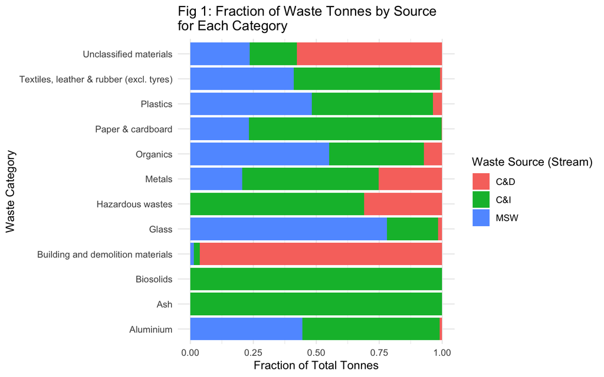

```r
# Step 3: Visualize - stacked bar chart showing the Stream fraction
# breakdown within each Category
ggplot(category_stream_fraction, aes(x = Category, y = Fraction, fill = Stream)) +
  geom_col(position = "fill") +
  coord_flip() +
  labs(
    title = "Fig 1: Fraction of Waste Tonnes by Source\nfor Each Category",
    x = "Waste Category",
    y = "Fraction of Total Tonnes",
    fill = "Waste Source (Stream)"
  ) +
  theme_minimal() +
  theme(plot.title = element_text(size = 13))
```

## Comment:

For each Category, total waste tonnes were aggregated by Stream (source) and converted into a fraction of the Category’s total.

# State-Level Waste Totals: Summary Statistics

```r
# ============================================================
# Total waste tonnes per Year/State -> temp,
# then Min/Max/Mean per State using a SINGLE R function
# ============================================================

# Step 1: Compute total waste tonnes for each Year x State combination
temp <- combined_data %>%
  filter(!is.na(Tonnes)) %>%
  group_by(Year, State) %>%
  summarise(Total_Tonnes = sum(Tonnes), .groups = "drop")

temp
```

| Year | State | Total_Tonnes |
| --- | --- | --- |
| 2006-2007 | ACT | 123348.03 |
| 2006-2007 | NSW | 12133529.10 |
| 2006-2007 | NT | 211021.81 |
| 2006-2007 | Qld | 8406112.29 |
| 2006-2007 | SA | 1133677.43 |
| 2006-2007 | Tas | 518567.28 |
| 2006-2007 | Vic | 10781625.74 |
| 2006-2007 | WA | 2845501.26 |
| 2007-2008 | ACT | 10254.25 |
| 2007-2008 | NSW | 1117130.60 |

[output cut: 111 more lines]

```r
# Step 2: Compute Min, Max, Mean of Total_Tonnes for EACH STATE
temp %>%
  group_by(State) %>%
  summarise(stats = list(summary(Total_Tonnes))) %>%
  { for (i in seq_len(nrow(.))) {
      cat("\nState:", .$State[i], "\n")
      print(.$stats[[i]])
    }
  }
```

```
##
## State: ACT
##    Min. 1st Qu.  Median    Mean 3rd Qu.    Max.
##   10254  114787  132197  261622  325202  939356
##
## State: Australia
##    Min. 1st Qu.  Median    Mean 3rd Qu.    Max.
##       0       0       0       0       0       0
##
## State: NSW
##     Min.  1st Qu.   Median     Mean  3rd Qu.     Max.
##  1117131 11563280 12788913 13952194 20919331 21707179
##
## State: NT
##    Min. 1st Qu.  Median    Mean 3rd Qu.    Max.
##   31372  144947  164031  153095  203092  247840
##
## State: Qld
##     Min.  1st Qu.   Median     Mean  3rd Qu.     Max.
##  1182726  7892444  8124255  8112047 10408971 13242400
##
## State: SA
##    Min. 1st Qu.  Median    Mean 3rd Qu.    Max.
##  350234 1141676 1298196 2317120 4212757 4641795
##
## State: Tas
##    Min. 1st Qu.  Median    Mean 3rd Qu.    Max.
##  270086  492305  548643  532748  624448  787984
##
## State: Vic
##     Min.  1st Qu.   Median     Mean  3rd Qu.     Max.
##  1035186 10404019 11466033 10142362 12698130 15468346
##
## State: WA
##    Min. 1st Qu.  Median    Mean 3rd Qu.    Max.
##  435379 2872095 5045902 3827965 5276943 6551575
```

## Comment:

Year and State were already available in combined_data through Year_State_ID. Total waste tonnes were aggregated for each Year–State combination and stored in temp. The summary() function was then applied to Total_Tonnes for each state to obtain the Min, Max, and Mean values, along with the quartiles and median. NSW and Victoria had the highest total waste tonnages, while “Australia” had zero across all statistics because no waste records were directly attributed to this aggregate entry.

# Yearly Trend: Food Organics Waste by State

```r
# ============================================================
# Convert Year-Year to a single Year value,
# then chart the yearly trend of Food Organics tonnes per state
# ============================================================

# Convert "YYYY-YYYY" financial year format into a single numeric Year
analysis_data <- combined_data %>%
  mutate(
    Year_numeric = as.numeric(str_sub(Year, 1, 4))
  )

# Confirm the conversion worked correctly
analysis_data %>%
  distinct(Year, Year_numeric) %>%
  arrange(Year_numeric) %>%
  print(n = Inf)
```

```
## # A tibble: 15 × 2
##    Year      Year_numeric
##    <chr>            <dbl>
##  1 2006-2007         2006
##  2 2007-2008         2007
##  3 2008-2009         2008
##  4 2009-2010         2009
##  5 2010-2011         2010
##  6 2011-2012         2011
##  7 2012-2013         2012
##  8 2013-2014         2013
##  9 2014-2015         2014
## 10 2015-2016         2015
## 11 2016-2017         2016
## 12 2017-2018         2017
## 13 2018-2019         2018
## 14 2019-2020         2019
## 15 2020-2021         2020
```

```r
# Filter for Food organics (Type = "Food organics"), aggregate tonnes
# by Year and State, excluding the "Australia" national aggregate row
food_organics_trend <- analysis_data %>%
  filter(Type == "Food organics", State != "Australia", !is.na(Tonnes)) %>%
  group_by(Year_numeric, State) %>%
  summarise(Total_Tonnes = sum(Tonnes), .groups = "drop")

food_organics_trend
```

| Year_numeric | State | Total_Tonnes |
| --- | --- | --- |
| 2006 | ACT | 55924.00 |
| 2006 | NSW | 1518923.00 |
| 2006 | NT | 84107.00 |
| 2006 | Qld | 892688.00 |
| 2006 | SA | 247329.00 |
| 2006 | Tas | 132097.00 |
| 2006 | Vic | 1316123.00 |
| 2006 | WA | 651059.00 |
| 2008 | ACT | 46602.00 |
| 2008 | NSW | 1694021.00 |

[output cut: 86 more lines]

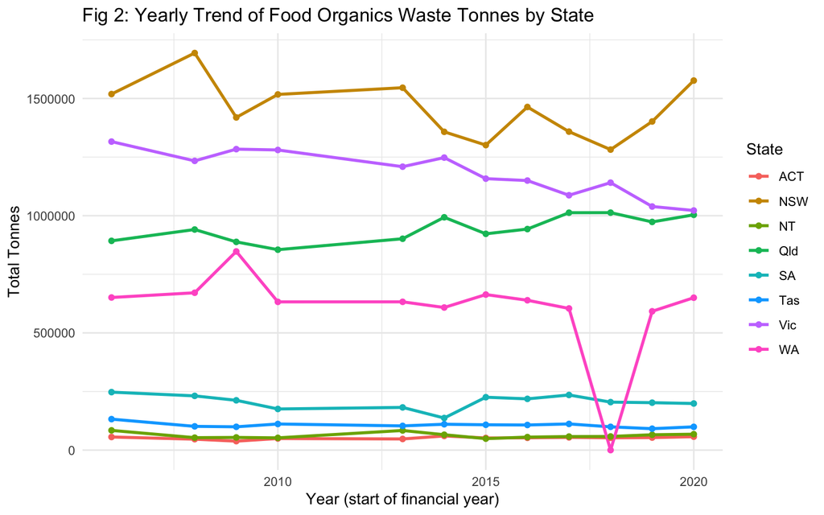

```r
# Visualize: yearly trend line, one line per state
ggplot(food_organics_trend, aes(x = Year_numeric, y = Total_Tonnes, color = State)) +
  geom_line(linewidth = 1) +
  geom_point() +
  labs(
    title = "Fig 2: Yearly Trend of Food Organics Waste Tonnes by State",
    x = "Year (start of financial year)",
    y = "Total Tonnes",
    color = "State"
  ) +
  theme_minimal()
```

```r
# Check whether 2007 has any Food organics records across states
analysis_data %>%
  filter(Type == "Food organics", Year_numeric == 2007) %>%
  nrow()
```

```
## [1] 0
```

## Comment:

The Year column (financial-year format, “2020-2021”) was converted to a single numeric year using the starting year of each financial period (Year_numeric), providing a continuous scale for trend analysis. Food organics tonnes were then aggregated by year and state and visualized as a line chart in Fig. 2. NSW and Victoria consistently show the largest volumes of food organics waste, while WA shows a sharp drop in reported tonnage in 2018 before recovering the following year.

# Which Waste Types Dominate Recycling, Energy Recovery, and Growth?

```r
# ============================================================
# Most recycled waste Type (with year)
# ============================================================

most_recycled <- analysis_data %>%
  filter(Fate == "Recycling", !is.na(Tonnes)) %>%
  group_by(Type, Year_numeric) %>%
  summarise(Total_Tonnes = sum(Tonnes), .groups = "drop") %>%
  arrange(desc(Total_Tonnes)) %>%
  slice(1)

most_recycled
```

| Type | Year_numeric | Total_Tonnes |
| --- | --- | --- |
| Bricks, concrete and pavers | 2020 | 10478681 |

## Comment:

Using analysis_data, waste tonnes were filtered for Fate = “Recycling” and totalled by Type and Year. The highest recorded value was Bricks, concrete and pavers in 2020, with approximately 10.48 million tonnes recycled.

```r
# ============================================================
# Most energy-recovered waste Type (with year)
# ============================================================

most_energy_recovered <- analysis_data %>%
  filter(Fate == "Energy recovery", !is.na(Tonnes)) %>%
  group_by(Type, Year_numeric) %>%
  summarise(Total_Tonnes = sum(Tonnes), .groups = "drop") %>%
  arrange(desc(Total_Tonnes)) %>%
  slice(1)

most_energy_recovered
```

| Type | Year_numeric | Total_Tonnes |
| --- | --- | --- |
| Food organics | 2015 | 1140998 |

## Comment:

For Fate = “Energy recovery”, tonnes were totalled by Type and Year. Food organics had the highest recorded energy recovery in 2015, at approximately 1.14 million tonnes.

```r
# ============================================================
# Most increased waste Type over years
# ============================================================

# Step 1: total tonnes per Type per year
type_yearly_totals <- analysis_data %>%
  filter(!is.na(Tonnes)) %>%
  group_by(Type, Year_numeric) %>%
  summarise(Total_Tonnes = sum(Tonnes), .groups = "drop")

# Step 2: for each Type, get its FIRST and LAST recorded year's tonnage
type_first_last <- type_yearly_totals %>%
  group_by(Type) %>%
  summarise(
    First_Year = min(Year_numeric),
    Last_Year = max(Year_numeric),
    First_Tonnes = Total_Tonnes[which.min(Year_numeric)],
    Last_Tonnes = Total_Tonnes[which.max(Year_numeric)],
    .groups = "drop"
  ) %>%
  mutate(
    Increase = Last_Tonnes - First_Tonnes,
    Pct_Increase = (Last_Tonnes - First_Tonnes) / First_Tonnes * 100
  )

# Step 3: the Type with the largest ABSOLUTE increase
most_increased_absolute <- type_first_last %>%
  arrange(desc(Increase)) %>%
  slice(1)

most_increased_absolute
```

| Type | First_Year | Last_Year | First_Tonnes | Last_Tonnes | Increase | Pct_Increase |
| --- | --- | --- | --- | --- | --- | --- |
| Bricks, concrete and pavers | 2006 | 2020 | 2133152 | 10478681 | 8345529 | 391.2299 |

```r
# For comparison: the Type with the largest PERCENTAGE increase
most_increased_pct <- type_first_last %>%
  arrange(desc(Pct_Increase)) %>%
  slice(1)

most_increased_pct
```

| Type | First_Year | Last_Year | First_Tonnes | Last_Tonnes | Increase | Pct_Increase |
| --- | --- | --- | --- | --- | --- | --- |
| Low density polyethylene (LDPE) (4) | 2006 | 2020 | 0 | 46183.74 | 46183.74 | Inf |

## Comment:

To identify the largest increase over time, the earliest and latest recorded tonnages for each Type were compared. Bricks, concrete and pavers had the largest absolute increase, rising from approximately 2.13 million tonnes in 2006 to 10.48 million tonnes in 2020, an increase of 8.35 million tonnes. Absolute increase was used instead of percentage change because some Types started at 0 tonnes, making percentage increases undefined or misleading.

# What Factors Influence Environmental Impact Scores?

```r
# ============================================================
# Factors influencing Environmental Impact Score
# ============================================================

# --- Factor 1: Does Impact_Score vary by Fate? ---
analysis_data %>%
  group_by(Fate) %>%
  summarise(
    Mean_Score = mean(Impact_Score, na.rm = TRUE),
    Median_Score = median(Impact_Score, na.rm = TRUE),
    n = n()
  ) %>%
  arrange(desc(Mean_Score))
```

| Fate | Mean_Score | Median_Score | n |
| --- | --- | --- | --- |
| Recycling | 6.179040 | 5 | 13941 |
| Energy recovery | 5.000000 | 5 | 7575 |
| Long-term storage | 5.000000 | 5 | 60 |
| Waste reuse | 5.000000 | 5 | 19 |
| Disposal | 4.746131 | 6 | 15122 |

## Comment:

- Fate: Impact_Score varies across waste management methods. Recycling has the highest mean score (6.18), while Disposal has the lowest (4.75). This suggests that how waste is managed is an important factor associated with the Environmental Impact Score, with recycling receiving higher scores than disposal.

```r
# --- Factor 2: Does Impact_Score vary by Category? ---
analysis_data %>%
  group_by(Category) %>%
  summarise(
    Mean_Score = mean(Impact_Score, na.rm = TRUE),
    n = n()
  ) %>%
  arrange(desc(Mean_Score))
```

| Category | Mean_Score | n |
| --- | --- | --- |
| Aluminium | 8.000000 | 3 |
| Metals | 6.691877 | 714 |
| Glass | 6.456311 | 309 |
| Plastics | 6.360465 | 946 |
| Building and demolition materials | 6.223060 | 928 |
| Paper & cardboard | 6.125000 | 696 |
| Ash | 6.032000 | 125 |
| Textiles, leather & rubber (excl. tyres) | 5.952632 | 380 |
| Biosolids | 5.619792 | 192 |
| Unclassified materials | 5.532847 | 137 |

[output cut: 2 more lines]

## Comment:

- Category: Impact_Score also varies across waste categories. Aluminium, Metals, and Glass have the highest mean scores (6.4–8.0), while Organics and Hazardous wastes have the lowest (4.9–5.3). This suggests that the type of waste is also associated with differences in Environmental Impact Score.

```r
# --- Factor 3: Correlation between Tonnes and Impact_Score ---
cor_tonnes <- cor.test(analysis_data$Tonnes, analysis_data$Impact_Score,
                        method = "pearson", use = "complete.obs")

cat("Correlation (Tonnes vs Impact Score):", round(cor_tonnes$estimate, 3), "\n")
```

```
## Correlation (Tonnes vs Impact Score): 0.071
```

```r
cat("p-value:", format.pval(cor_tonnes$p.value, digits = 3), "\n")
```

```
## p-value: <2e-16
```

## Comment:

- Tonnes: The Pearson correlation between waste quantity (Tonnes) and Impact_Score is r = 0.071 (p < 0.001). Although statistically significant, the correlation is very weak, indicating that the amount of waste has little practical relationship with the Environmental Impact Score.

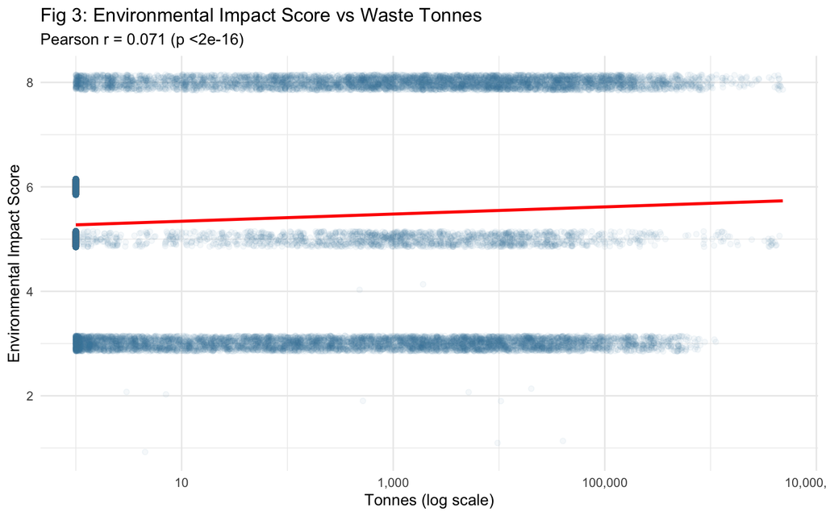

```r
# Visual for Factor 3: Tonnes vs Impact_Score (log-scale, since Tonnes is extremely skewed)
ggplot(analysis_data %>% filter(!is.na(Tonnes), !is.na(Impact_Score)),
       aes(x = Tonnes + 1, y = Impact_Score)) +
  geom_jitter(alpha = 0.05, width = 0, height = 0.15, color = "steelblue") +
  geom_smooth(method = "lm", color = "red", se = FALSE) +
  scale_x_log10(labels = scales::comma) +
  labs(
    title = "Fig 3: Environmental Impact Score vs Waste Tonnes",
    subtitle = paste0("Pearson r = ", round(cor_tonnes$estimate, 3),
                       " (p ", format.pval(cor_tonnes$p.value, digits = 2), ")"),
    x = "Tonnes (log scale)",
    y = "Environmental Impact Score"
  ) +
  theme_minimal()
```

## Comment:

- Fig. 3 shows the relationship between waste quantity and Environmental Impact Score on a log-scaled x-axis. The scores remain clustered across a wide range of waste quantities, with the fitted line showing only a slight positive trend. This supports the correlation result (r = 0.071), indicating that waste quantity has little practical influence on the Impact_Score.

```r
# --- Factor 4: Correlation between Economic_Growth and Impact_Score ---
cor_growth <- cor.test(analysis_data$Economic_Growth, analysis_data$Impact_Score,
                        method = "pearson", use = "complete.obs")

cat("Correlation (Economic Growth vs Impact Score):", round(cor_growth$estimate, 3), "\n")
```

```
## Correlation (Economic Growth vs Impact Score): -0.022
```

```r
cat("p-value:", format.pval(cor_growth$p.value, digits = 3), "\n")
```

```
## p-value: 1.62e-05
```

## Comment:

- Economic Growth: The Pearson correlation between Economic_Growth and Impact_Score is r = -0.022 (p < 0.001). Although statistically significant, the correlation is extremely weak, indicating that economic growth has little practical relationship with the Environmental Impact Score.

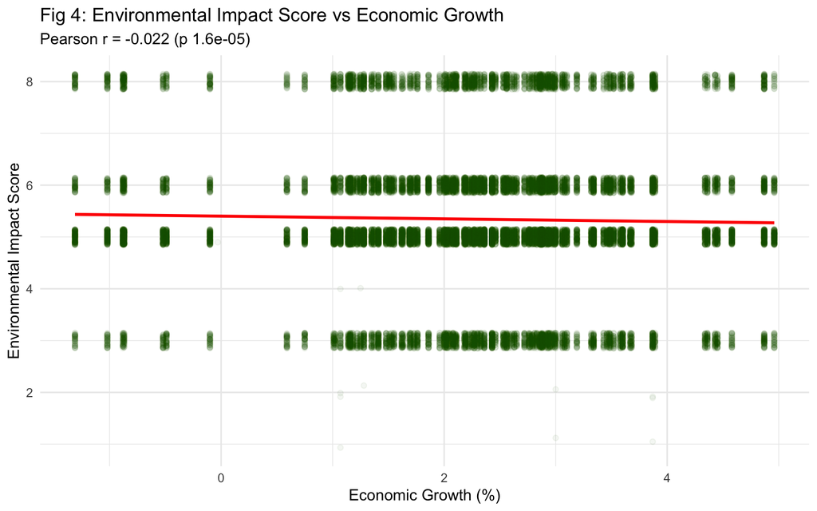

```r
# Visual for Factor 4: Economic_Growth vs Impact_Score
ggplot(analysis_data %>% filter(!is.na(Economic_Growth), !is.na(Impact_Score)),
       aes(x = Economic_Growth, y = Impact_Score)) +
  geom_jitter(alpha = 0.05, width = 0, height = 0.15, color = "darkgreen") +
  geom_smooth(method = "lm", color = "red", se = FALSE) +
  labs(
    title = "Fig 4: Environmental Impact Score vs Economic Growth",
    subtitle = paste0("Pearson r = ", round(cor_growth$estimate, 3),
                       " (p ", format.pval(cor_growth$p.value, digits = 2), ")"),
    x = "Economic Growth (%)",
    y = "Environmental Impact Score"
  ) +
  theme_minimal()
```

## Comment:

- Fig. 4 shows the relationship between Economic_Growth and Environmental Impact Score. The data points are widely dispersed, and the fitted line is almost flat, indicating little to no clear relationship between economic growth and Impact_Score. This is consistent with the very weak Pearson correlation (r = -0.022).

## Conclusion:

# Tyre Disposal Patterns: A State Investment Case Study

```r
# ============================================================
# Tyre disposal size variation & frequency by state
# ============================================================

# Filter for tyre waste (Type contains "Tyres")
tyre_data <- analysis_data %>%
  filter(str_detect(Type, "Tyres"), !is.na(Tonnes))

# Check the range of Tonnes for tyres, to choose sensible bin boundaries
summary(tyre_data$Tonnes)
```

```
##    Min. 1st Qu.  Median    Mean 3rd Qu.    Max.
##       0       0       0    3906       0   70411
```

```r
# Create Tonnes_range bins (at least 4 ranges)
tyre_data <- tyre_data %>%
  mutate(
    Tonnes_range = cut(
      Tonnes,
      breaks = c(-Inf, 0, 10, 100, 1000, Inf),
      labels = c("0", "0-10", "10-100", "100-1000", "1000+"),
      right = TRUE
    )
  )

# Check how the bins distributed
tyre_data %>% count(Tonnes_range)
```

| Tonnes_range | n |
| --- | --- |
| 0 | 1180 |
| 10-100 | 2 |
| 100-1000 | 46 |
| 1000+ | 344 |

```r
# Look at the distribution of NON-ZERO tyre tonnage specifically,
tyre_data %>%
  filter(Tonnes > 0) %>%
  pull(Tonnes) %>%
  summary()
```

```
##    Min. 1st Qu.  Median    Mean 3rd Qu.    Max.
##      86    1738    8267   15662   26736   70411
```

```r
# How many tyre records are there in total, and how many are zero vs non-zero?
nrow(tyre_data)
```

```
## [1] 1572
```

```r
sum(tyre_data$Tonnes == 0)
```

```
## [1] 1180
```

```r
sum(tyre_data$Tonnes > 0)
```

```
## [1] 392
```

```r
# Look at quantiles of the non-zero values to pick sensible bin cutpoints
tyre_data %>%
  filter(Tonnes > 0) %>%
  pull(Tonnes) %>%
  quantile(probs = c(0.25, 0.5, 0.75, 0.9, 0.95, 1))
```

```
##       25%       50%       75%       90%       95%      100%
##  1738.003  8266.632 26735.765 47009.285 56994.921 70411.023
```

```r
# ============================================================
# Build meaningful Tonnes_range bins
# ============================================================

# Bin boundaries chosen based on the actual quantiles of non-zero tyre tonnage:
# - "0" isolates the no-disposal-recorded cases (75% of records)
tyre_data <- tyre_data %>%
  mutate(
    Tonnes_range = cut(
      Tonnes,
      breaks = c(-Inf, 0, 2000, 10000, 30000, Inf),
      labels = c("0 (none)", "1-2,000", "2,001-10,000", "10,001-30,000", "30,000+"),
      right = TRUE
    )
  )

# Check the new bin distribution
tyre_data %>% count(Tonnes_range)
```

| Tonnes_range | n |
| --- | --- |
| 0 (none) | 1180 |
| 1-2,000 | 114 |
| 2,001-10,000 | 93 |
| 10,001-30,000 | 109 |
| 30,000+ | 76 |

```r
# Frequency of each Tonnes_range PER STATE
tyre_state_summary <- tyre_data %>%
  count(State, Tonnes_range)

print(tyre_state_summary, n = Inf)
```

```
## # A tibble: 31 × 3
##    State Tonnes_range      n
##    <chr> <fct>         <int>
##  1 ACT   0 (none)        145
##  2 ACT   1-2,000          34
##  3 ACT   2,001-10,000     15
##  4 NSW   0 (none)        148
##  5 NSW   2,001-10,000     15
##  6 NSW   10,001-30,000     8
##  7 NSW   30,000+          26
##  8 NT    0 (none)        148
##  9 NT    1-2,000          38
## 10 NT    2,001-10,000     11
## 11 Qld   0 (none)        147
## 12 Qld   1-2,000           4
```

[output cut: 19 more lines]

## Comment:

Tyre records were identified by filtering Type values containing “Tyres”. The data showed that 1,180 of the 1,572 records had zero tonnes, while the 392 non-zero records ranged from 86 to 70,411 tonnes. Based on the distribution of the non-zero values, five Tonnes_range categories were created, with “0 (none)” separated from the actual disposal ranges. This allowed genuine disposal activity to be analysed without the large number of zero-tonnage records obscuring the results.

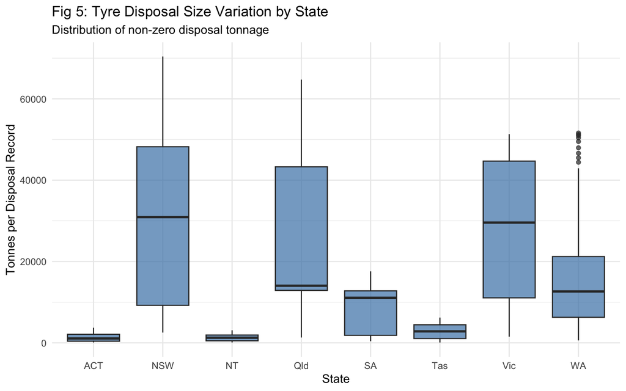

```r
# ============================================================
# Two focused visuals - size variation
# and frequency of MEANINGFUL disposal activity
# ============================================================

# --- Visual A: Disposal SIZE VARIATION per state (boxplot, non-zero only) ---
ggplot(tyre_data %>% filter(Tonnes > 0), aes(x = State, y = Tonnes)) +
  geom_boxplot(fill = "steelblue", alpha = 0.7) +
  labs(
    title = "Fig 5: Tyre Disposal Size Variation by State",
    subtitle = "Distribution of non-zero disposal tonnage",
    x = "State",
    y = "Tonnes per Disposal Record"
  ) +
  theme_minimal()
```

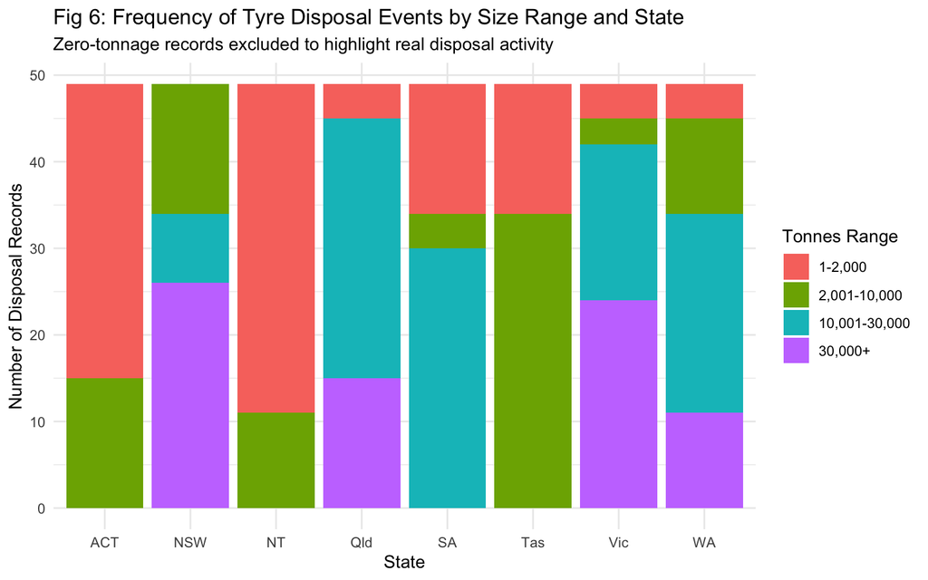

```r
# --- Visual B: Disposal FREQUENCY by size range per state (excluding "0 (none)") ---
tyre_state_summary_nonzero <- tyre_data %>%
  filter(Tonnes > 0) %>%
  count(State, Tonnes_range)

ggplot(tyre_state_summary_nonzero, aes(x = State, y = n, fill = Tonnes_range)) +
  geom_col(position = "stack") +
  labs(
    title = "Fig 6: Frequency of Tyre Disposal Events by Size Range and State",
    subtitle = "Zero-tonnage records excluded to highlight real disposal activity",
    x = "State",
    y = "Number of Disposal Records",
    fill = "Tonnes Range"
  ) +
  theme_minimal()
```

## Comment:

Overall, the results show substantial differences in tyre disposal size and frequency between states. NSW, Vic, and Qld have the largest and most variable disposal events, while ACT, NT, and Tas generally have smaller disposal amounts.

## Recommendation:

NSW, Vic, and Qld are the strongest candidates for large-scale tyre processing investment as they combine both high disposal volumes and high frequency of large-scale events, indicating consistent demand for high-capacity processing infrastructure.

# What’s Driving the Growth in Construction & Demolition Waste?

```r
# ============================================================
# Yearly trend of total C&D waste tonnes
# ============================================================

cd_yearly_trend <- analysis_data %>%
  filter(Stream == "C&D", !is.na(Tonnes)) %>%
  group_by(Year_numeric) %>%
  summarise(Total_Tonnes = sum(Tonnes), .groups = "drop")

cd_yearly_trend
```

| Year_numeric | Total_Tonnes |
| --- | --- |
| 2006 | 5314915 |
| 2007 | 2095537 |
| 2008 | 5314525 |
| 2009 | 5789373 |
| 2010 | 5850830 |
| 2011 | 1339393 |
| 2012 | 1463712 |
| 2013 | 7279393 |
| 2014 | 11394013 |
| 2015 | 14414755 |

[output cut: 5 more lines]

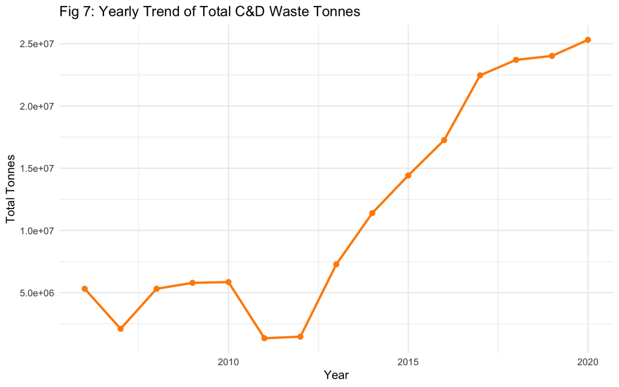

```r
ggplot(cd_yearly_trend, aes(x = Year_numeric, y = Total_Tonnes)) +
  geom_line(color = "darkorange", linewidth = 1) +
  geom_point(color = "darkorange", size = 2) +
  labs(
    title = "Fig 7: Yearly Trend of Total C&D Waste Tonnes",
    x = "Year",
    y = "Total Tonnes"
  ) +
  theme_minimal()
```

```r
# Also check: whether Economic_Growth correlates with total C&D tonnes per year
cd_growth_check <- analysis_data %>%
  filter(Stream == "C&D", !is.na(Tonnes)) %>%
  group_by(Year_numeric) %>%
  summarise(
    Total_Tonnes = sum(Tonnes),
    Avg_Economic_Growth = mean(Economic_Growth, na.rm = TRUE),
    .groups = "drop"
  )

cd_growth_check
```

| Year_numeric | Total_Tonnes | Avg_Economic_Growth |
| --- | --- | --- |
| 2006 | 5314915 | 2.4730036 |
| 2007 | 2095537 | 2.1125000 |
| 2008 | 5314525 | 2.7262355 |
| 2009 | 5789373 | 3.1537321 |
| 2010 | 5850830 | 2.4715192 |
| 2011 | 1339393 | 2.7762500 |
| 2012 | 1463712 | 2.4625000 |
| 2013 | 7279393 | 2.3209643 |
| 2014 | 11394013 | 2.4319140 |
| 2015 | 14414755 | 2.8713891 |

[output cut: 5 more lines]

```r
cor.test(cd_growth_check$Total_Tonnes, cd_growth_check$Avg_Economic_Growth)
```

```
##
##  Pearson's product-moment correlation
##
## data:  cd_growth_check$Total_Tonnes and cd_growth_check$Avg_Economic_Growth
## t = -1.8274, df = 13, p-value = 0.09068
## alternative hypothesis: true correlation is not equal to 0
## 95 percent confidence interval:
##  -0.78300766  0.07832752
## sample estimates:
##        cor
## -0.4520745
```

## Comment:

- Total C&D waste tonnes were aggregated by year using analysis_data. In fig 7, the yearly totals were relatively volatile from 2006–2012, ranging from approximately 1.3 to 5.9 million tonnes. From 2013 onwards, the trend increased substantially and consistently, reaching approximately 25.3 million tonnes in 2020. This represents a major increase compared with the earlier years, although the sharp changes in the early period suggest that factors other than construction activity may also have influenced the reported totals.

The relationship between yearly C&D waste tonnes and average Economic_Growth was moderately negative (r = -0.45), but the relationship was not statistically significant (p = 0.091). Therefore, the available economic growth measure does not provide strong evidence that annual economic growth directly explains the increase in C&D waste tonnes.

```r
# ============================================================
# Contextualise trend against external factors
# ============================================================

# National Waste Report reference: ~19.0 million tonnes of C&D waste nationally
# in 2008-09 (Construction and Demolition Waste Status Report, DCCEEW 2011)
# vs. our filtered/cleaned dataset subset for 2009:
cd_yearly_trend %>% filter(Year_numeric == 2009)
```

| Year_numeric | Total_Tonnes |
| --- | --- |
| 2009 | 5789373 |

```r
# National Waste Report reference: 27 million tonnes in 2019-20
# vs. our dataset for 2019/2020:
cd_yearly_trend %>% filter(Year_numeric %in% c(2019, 2020))
```

| Year_numeric | Total_Tonnes |
| --- | --- |
| 2019 | 24021548 |
| 2020 | 25313728 |

## Comment:

The trend was also compared with figures from the National Waste Report. The report estimated approximately 19 million tonnes of C&D waste nationally in 2008–09(DCCEEW, Construction and Demolition Waste Status Report, 2011: https://www.dcceew.gov.au/environment/protection/waste/publications/construction-and-demolition-waste-status-report), compared with 5.79 million tonnes in the cleaned dataset for 2009. For 2019–20, the report estimated approximately 27 million tonnes, while the dataset records 24.02 million tonnes in 2019 and 25.31 million tonnes in 2020. The difference in earlier years may reflect differences in coverage, definitions, and reporting methods rather than a direct contradiction between the datasets.

## Conclusion:

This analysis of the National Waste Report 2022 dataset identified and addressed a range of data quality issues: inconsistent category labels, a corrupted tonnage value, missing values, and duplicate identifiers before proceeding to substantive analysis. Key findings relevant to investment decisions include:

- Waste sources vary by category, with Biosolids and Ash entirely from C&I sources and Glass mainly from MSW.
- Hazardous wastes and Organics have the lowest average Impact Scores, with Fate appearing more influential than waste volume or economic growth.
- Bricks, concrete and pavers had the highest recycled volume and largest absolute increase from 2006–2020.
- Tyre disposal volumes and large-scale events were highest in NSW, Victoria, and Queensland, highlighting areas for potential processing investment.

Overall, C&D waste shows a strong upward trend in fig 7 from 2013 to 2020, while Economic_Growth alone does not provide a statistically significant explanation for this increase. The comparison with national waste estimates supports the general scale and direction of the trend, but differences in dataset scope and reporting should be considered. The large fluctuations in the earlier years also suggest that changes in data coverage or reporting practices may have contributed to the observed trend.